# Fitting the ST model for the LUR

Sheena Martenies

04/20/2020

### Description:

After meeting with Josh Keller (Statistics, CSU), we decided to try to implement the modeling framework used by the MESA Air team (Keller et al., 2015). This was implemented using the SpatioTemporal package in R.

The original paper used PLS to select the spatial covariates. That will be the eventual approach for this analysis, but for now, I’m going to use the covariates selected by the LASSO model (see 16a_LUR_BC_average.R)

**Update 03.18.20**: I was receiving an error when trying to use the estimate.STmodel() function from the SpatioTemporal package. I emailed Josh Keller for advice, and he responded with some suggestions. I’ve pasted his email response at the end of this script for safe keeping

Basically, I’m going to start with the following:

- Simple model (i.e., only one time trend)
- iid covariance structure

**Update 03.24.20**: Sheryl and I met with Josh Keller again today to go over the premliminary verison of the model and talk about next steps. Here are some of the take-aways from the meeting:

- We should add the entirety of the BC monitoring data at the central site to help establish long-term time trends
- We need to add degrees of freedom to the time trends. Josh recommended 4 per year (but we can also try 8, 12, etc.). Time trends will become more obvious with more data
- I need to use the PM and NO2 monitoring data to establish temporal trends. These are different from the ST predictors! Start by plotting the time trends of PM, temp, and NO2. We might want to use PM for the temporal trends and NO2 and Temp as ST predictors (other combinations might work too, such as adding PM to the ST predictors). Don’t use BC as a ST predictor
  - When looking at the temporal trends, use `createSTdata`
  - Need to standardize PM and NO2
  - When ready to create the `STdata` object for model fitting, assign the temporal trend dataset to the `$trend` slot of the `STdata` object
- We also want to run a model without ST predictors as a comparison
- Make the LUR function the same for the intercept and the time trends
- Rather than set `nugget = ~type`, set `nugget = T`
- Change from the `iid` covariance structure to the `exp` structure
- Run a number of initial conditions to try to find the right minimum
  - For nuggets, set them to between -1 and -6
  - For ranges, set them to between 0 and 4
- Cross validation!
  - For distributed sites, use 10-fold CV
  - For central site, use LOOCV
- There is a trade-off for the number of basis functions selected. For now, I’m going to stick with one, and then we can see if more make sense later

**Update 04.20.20**: So far, it looks like I’ve been able to fit the model using the long-term PM data (scaled) for the temporal trends. There are still some outstanding things I need to work on:

- [] Adding additional ST covariates (*e.g.*, smoke days, temperature)
- [] Using PLS to identify spatial covariates
- [] Figure out how to predict to the full grid

I’m going to stick with the LASSO-selected spatial predictors for now. In the future, I’ll be implementing PLS.

### Step 1. Data formatting

Josh Keller made key revisions to the estimate.STmodel() function. Loading his version here and examining the objects from the `SpatioTemporal` package

Get my data to match the Mesa data set. When I ran this the first time, Site 61 looked much different from the others, so I dropped it for now. I’ll need to go back and figure out what was wonky about that site later.

Loading the data sets needed for the analysis. Filtering out indoor filters, filters missing spatial data, and filters with BC concentrations below 0.

Something is going on with Site 61. When calculating the beta fields, I got results that were an order of magnitude larger than for the other sites. How does this site differ from the others?

The plots below suggest that maybe there is a different temporal pattern at this site? It’s not far from other sites, but we only have one campaign’s worth of data here. I’m going to drop it for now, but I’ll plan to come back to this eventually.

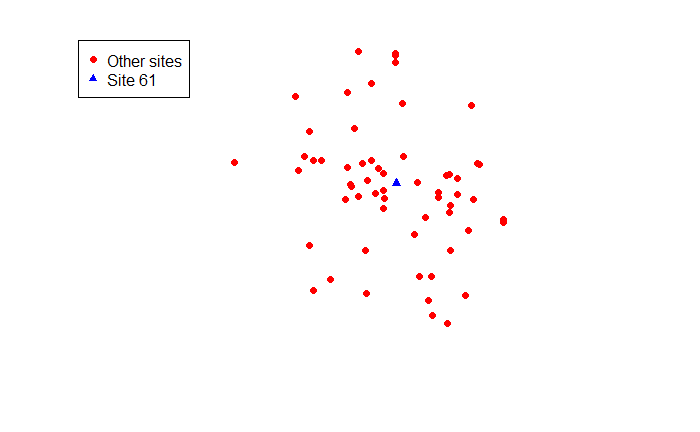

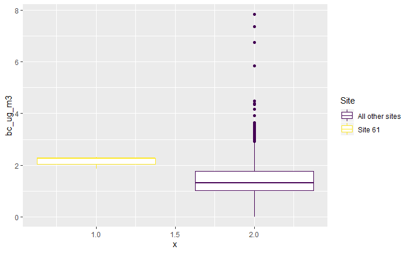

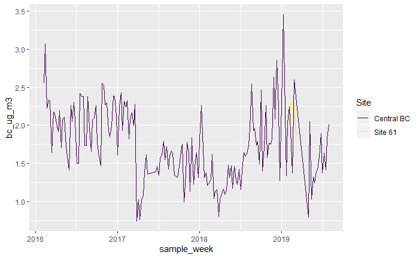

```r
d61_data <- filter(lur_data, site_id == "d_61") %>%
  st_as_sf(wkt = "WKT", crs = albers)
other_data <- filter(lur_data, site_id != "d_61") %>%
  st_as_sf(wkt = "WKT", crs = albers)

plot(st_geometry(other_data), col = "red", pch = 16)
plot(st_geometry(d61_data), col = "blue", add = T, pch = 17)
legend(x = "topleft", c("Other sites", "Site 61"),
       pch = c(16, 17),
       col = c("red", "blue"))

ggplot() +
  geom_boxplot(data = d61_data, aes(x = 1, y = bc_ug_m3, col = "d61")) +
  geom_boxplot(data = other_data, aes(x = 2, y = bc_ug_m3, col = "all")) +
  scale_color_viridis(name = "Site", discrete = T,
                      labels = c("d61" = "Site 61",
                                 "all" = "All other sites"))


ggplot() +
  geom_line(data = d61_data, aes(x = sample_week, y = bc_ug_m3, col = "d61")) +
  geom_line(data = filter(other_data, filter_id == "080310027"),
            aes(x = sample_week, y = bc_ug_m3, col = "cent")) +
  scale_color_viridis(name = "Site", discrete = T,
                      labels = c("d61" = "Site 61",
                                 "cent" = "Central BC"))
```

```r
#' Filter out site 61
lur_data <- filter(lur_data, site_id != "d_61")
```

Observations of black carbon at the distributed and central sites. Make sure to use log-transformed values!

```r
bc_obs <- lur_data %>%
  select(site_id, sample_week, bc_ug_m3) %>%
  mutate(log_bc = log(bc_ug_m3)) %>%
  select(-bc_ug_m3) %>%
  pivot_wider(id_cols = sample_week,
              names_from = site_id, values_from = log_bc) %>%
  as.data.frame() %>%
  arrange(sample_week)
rownames(bc_obs) <- bc_obs$sample_week
bc_obs$sample_week <- NULL
bc_obs <- as.matrix(bc_obs)

bc_weeks <- rownames(bc_obs)

# rownames(bc_obs)
# colnames(bc_obs)
class(bc_obs)
```

```
[1] "matrix"
```

```r
dim(bc_obs)
```

```
[1] 170  61
```

Spatial covariates at the distributed site. These are based on the LASSO model (THIS WILL CHANGE IN THE FUTURE!! I just know how to use LASSO vs. PLS). Make sure the covariates are scaled here.

```r
covars
```

```
[1] "tree_cover_100"  "low_int_100"     "dist_m_military" "dist_m_rail"     "aadt_100"
```

```r
bc_sp_cov <- select(lur_data, site_id, lon, lat, covars) %>%
  distinct() %>%
  mutate_at(.vars = vars(covars),
            scale)

bc_sp_cov <- bc_sp_cov %>%
  rename(ID = site_id) %>%
  mutate(lon2 = lon, lat2 = lat) %>%
  st_as_sf(coords = c("lon2", "lat2"), crs = ll_wgs84) %>%
  st_transform(crs = albers)
sp_coords <- do.call(rbind, st_geometry(bc_sp_cov)) %>%
  as_tibble() %>% setNames(c("x","y"))
```

```
`as_tibble.matrix()` requires a matrix with column names or a `.name_repair` argument. Using compatibility `.name_repair`.
```

```r
bc_sp_cov <- bind_cols(bc_sp_cov, sp_coords) %>%
  st_set_geometry(NULL) %>%
  as.data.frame()

bc_sp_cov$type <- ifelse(bc_sp_cov$ID == "central", "central", "dist")
bc_sp_cov$type <- as.factor(bc_sp_cov$type)
bc_sp_cov$type
```

```
 [1] central dist    dist    dist    dist    dist    dist    dist    dist    dist    dist    dist    dist    dist    dist
[16] dist    dist    dist    dist    dist    dist    dist    dist    dist    dist    dist    dist    dist    dist    dist
[31] dist    dist    dist    dist    dist    dist    dist    dist    dist    dist    dist    dist    dist    dist    dist
[46] dist    dist    dist    dist    dist    dist    dist    dist    dist    dist    dist    dist    dist    dist    dist
[61] dist
Levels: central dist
```

```r
# head(bc_sp_cov)
class(bc_sp_cov)
```

```
[1] "data.frame"
```

```r
cor(bc_sp_cov[,c(4:8)])
```

```
                tree_cover_100 low_int_100 dist_m_military dist_m_rail   aadt_100
tree_cover_100      1.00000000  0.17021147      0.19563553 -0.02100465 -0.2014628
low_int_100         0.17021147  1.00000000      0.04177673 -0.01893110 -0.2846444
dist_m_military     0.19563553  0.04177673      1.00000000 -0.20139840  0.1311750
dist_m_rail        -0.02100465 -0.01893110     -0.20139840  1.00000000 -0.1980653
aadt_100           -0.20146284 -0.28464438      0.13117498 -0.19806530  1.0000000
```

Spatiotemporal covariates at the distributed sites. We have available IDW estimates of temp, NO2, PM2.5, and BC. For now, just using NO2, since the correlations with distribued site log(BC) are decent. I tried to use two ST predictors, but ran into issues trying to fit the model.

```r
cor(log(lur_data$bc_ug_m3), lur_data$idw_no2, use = "complete")
```

```
[1] 0.4016744
```

```r
cor(log(lur_data$bc_ug_m3), lur_data$idw_pm, use = "complete")
```

```
[1] 0.1219526
```

```r
cor(log(lur_data$bc_ug_m3), lur_data$idw_temp, use = "complete")
```

```
[1] -0.4692052
```

### Step 2. create the ST data object and determine the number of basis functions for the temporal trend

For now, going to use one ST predictor (NO2 estimated for each sampling location). Josh advised 4 degrees of freedom per year. Going to check the SVDsmoothCV results for 4 DF per year.

```r
denver.data <- createSTdata(obs = bc_obs,
                            covars = bc_sp_cov,
                            SpatioTemporal = list(bc_st_no2 = bc_st_no2))
D <- createDataMatrix(denver.data)
# names(denver.data)
# print(denver.data)

# Determine the number of basis functions
n_years <- length(unique(as.Date(cut(as.Date(rownames(bc_obs)), "year"))))

SVD.cv.4py <- SVDsmoothCV(D, 0:4, df = 4*n_years)
print(SVD.cv.4py)
```

```
Result of SVDsmoothCV, average of CV-statistics:
```

|  | MSE | R2 | AIC | BIC |
| --- | --- | --- | --- | --- |
| n.basis.0 | 0.20299386 | 0.0000000 | -89.95763 | -88.77611 |
| n.basis.1 | 0.13463631 | 0.4301274 | -102.16152 | -99.79848 |
| n.basis.2 | 0.10715020 | 0.5565813 | -111.35271 | -107.80815 |
| n.basis.3 | 0.07861279 | 0.6532588 | -118.80793 | -114.08184 |
| n.basis.4 | 0.07306526 | 0.6653271 | -117.32605 | -111.41845 |

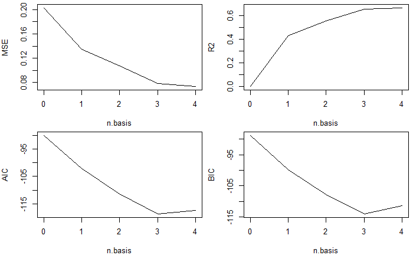

```r
plot(SVD.cv.4py)
```

```r
n_df <- 4
n_basis <- 1

# Add the smooth temporal basis functions to the ST data object
denver.data <- updateTrend(denver.data, n.basis = n_basis, df = n_df*n_years)
```

```
Replacing existing trend.
```

```r
head(denver.data$trend)
```

|  | V1 | date |
| --- | --- | --- |
| 1 | -2.098664 | 2016-02-08 |
| 2 | -1.934761 | 2016-02-15 |
| 3 | -1.771717 | 2016-02-22 |
| 4 | -1.612352 | 2016-02-29 |
| 5 | -1.459932 | 2016-03-07 |
| 6 | -1.317676 | 2016-03-14 |

```r
plot(denver.data$trend$date, denver.data$trend$V1, col = 1, pch = 16, cex = 0.5,
     xlab = "Date", ylab = "BC",
     main = "Basis function")
# points(denver.data$trend$date, denver.data$trend$V2, col = 2, pch = 16, cex = 0.5)

layout(matrix(c(1,2,1,3), 2, 2))
```

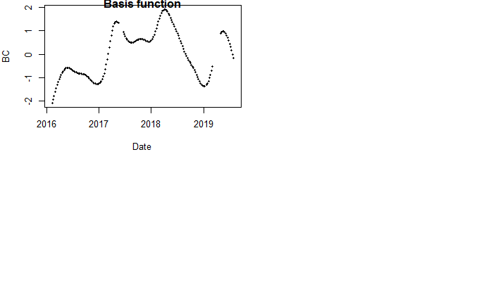

```r
par(mar=c(2.3,3.3,2,1), mgp=c(2,1,0))
```

```r
plot(denver.data, "loc", main="Occurrence of Observations", xlab="",
     ylab="Location", col=c("black", "red"), legend.loc=NULL)
par(mar=c(3.3,3.3,2,1))
```

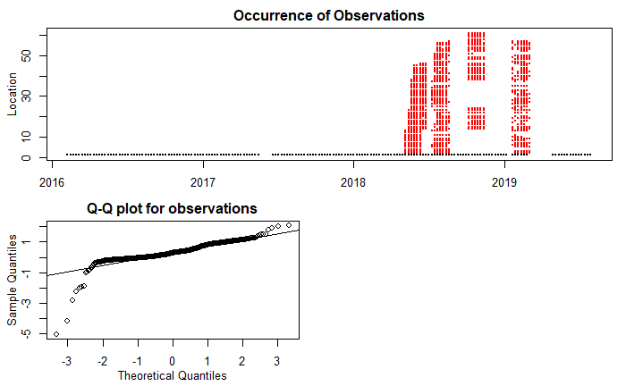

```r
qqnorm(denver.data, line=1)
scatterPlot(denver.data, covar="aadt_100", xlab="AADT in a 100 m buffer",
            ylab="BC (log ug/m3)", pch=19, cex=.25,
            smooth.args=list(span=4/5,degree=2))
```

### Step 3: Evaluate the basis functions

Plotting the temporal trends at a few of the sites

```r
par(mar=c(3.3,3.3,1.5,1), mgp=c(2,1,0))
layout(matrix(c(1,1,2,2,3,4), 3, 2, byrow=TRUE))
plot(denver.data, "obs", ID="d_1", xlab="", ylab="BC (log ug/m3)",
     main="Temporal trend d_1")
plot(denver.data, "res", ID="d_1", xlab="", ylab="BC (log ug/m3)")
plot(denver.data, "acf", ID="d_1")
plot(denver.data, "pacf", ID="d_1")

par(mar=c(3.3,3.3,1.5,1), mgp=c(2,1,0))
layout(matrix(c(1,1,2,2,3,4), 3, 2, byrow=TRUE))
plot(denver.data, "obs", ID="d_20", xlab="", ylab="BC (log ug/m3)",
     main="Temporal trend d_20")
plot(denver.data, "res", ID="d_20", xlab="", ylab="BC (log ug/m3)")
plot(denver.data, "acf", ID="d_20")
plot(denver.data, "pacf", ID="d_20")

par(mar=c(3.3,3.3,1.5,1), mgp=c(2,1,0))
layout(matrix(c(1,1,2,2,3,4), 3, 2, byrow=TRUE))
plot(denver.data, "obs", ID="d_53", xlab="", ylab="BC (log ug/m3)",
     main="Temporal trend d_53")
plot(denver.data, "res", ID="d_53", xlab="", ylab="BC (log ug/m3)")
plot(denver.data, "acf", ID="d_53")
plot(denver.data, "pacf", ID="d_53")

par(mar=c(3.3,3.3,1.5,1), mgp=c(2,1,0))
layout(matrix(c(1,1,2,2,3,4), 3, 2, byrow=TRUE))
plot(denver.data, "obs", ID="central", xlab="", ylab="BC (log ug/m3)",
     main="Temporal trend central")
plot(denver.data, "res", ID="central", xlab="", ylab="BC (log ug/m3)")
plot(denver.data, "acf", ID="central")
plot(denver.data, "pacf", ID="central")
```

[output not shown]

### Step 4: Fit the model

#### Step 4.1: Compute the regression coefficients

```r
names(denver.data$covars)
```

```
 [1] "ID"              "lon"             "lat"             "tree_cover_100"  "low_int_100"     "dist_m_military"
 [7] "dist_m_rail"     "aadt_100"        "x"               "y"               "type"
```

```r
beta.lm <- estimateBetaFields(denver.data)
# beta_lm
head(beta.lm$beta)
```

```
             const         V1
central  0.5177285 -0.2058371
d_1      0.2067486 -0.1782019
d_10    -0.1786499  0.1260858
d_11     0.3366226 -0.2319377
d_12     0.1629331 -0.3437508
d_13     0.2941855 -0.1486549
```

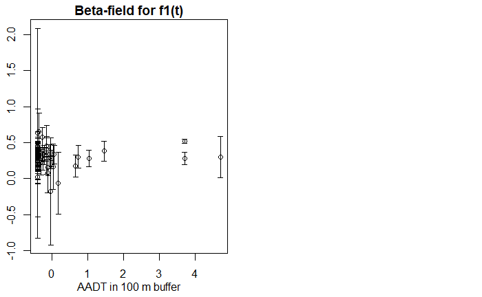

```r
par(mfrow=c(1,2), mar=c(3.3,2.3,1.5,1), mgp=c(2,1,0))
plotCI(denver.data$covars$aadt_100, beta.lm$beta[,1],
       uiw=1.96*beta.lm$beta.sd[,1], ylab="", xlab="AADT in 100 m buffer",
       main="Beta-field for f1(t)")
plotCI(denver.data$covars$tree_cover_100, beta.lm$beta[,2],
       uiw=1.96*beta.lm$beta.sd[,2], ylab="", xlab="%Tree cover in 100 m buffer",
       main="Beta-field for f2(t)")
```

#### Step 4.2: Create the model object (iid covariance structure)

Here we can specify different LUR formluae. The length of the LUR list should be number of basis functions + 1.

I’m going to start with the `iid` covariance structure and will be setting `nugget = T`.

```r
names(denver.data$covars)
```

```
 [1] "ID"              "lon"             "lat"             "tree_cover_100"  "low_int_100"     "dist_m_military"
 [7] "dist_m_rail"     "aadt_100"        "x"               "y"               "type"
```

```r
LUR <- list(~tree_cover_100 + low_int_100 + dist_m_military + dist_m_rail + aadt_100,
            ~tree_cover_100 + low_int_100 + dist_m_military + dist_m_rail + aadt_100)
cov.beta <-  list(covf="iid", nugget = T)
cov.nu <- list(covf="iid", nugget = T, random.effect = FALSE)
locations <- list(coords = c("x","y"), long.lat = c("lon","lat"), others= "type")

denver.model.iid <- createSTmodel(denver.data, LUR = LUR,
                                  ST = "bc_st_no2",
                                  cov.beta = cov.beta, cov.nu = cov.nu,
                                  locations = locations)
denver.model.iid
```

```
STmodel-object with:
    No. locations: 61 (observed: 61)
    No. time points: 170 (observed: 170)
    No. obs: 1146

Trend with 1 basis function(s):
[1] "V1"
with dates:
    2016-02-08 to 2019-07-29

Models for the beta-fields are:
$const
~tree_cover_100 + low_int_100 + dist_m_military + dist_m_rail +
    aadt_100

$V1
~tree_cover_100 + low_int_100 + dist_m_military + dist_m_rail +
    aadt_100

1 spatio-temporal covariate(s):
[1] "bc_st_no2"

Covariance model for the beta-field(s):
    Covariance type(s): iid, iid
    Nugget: Yes, Yes
Covariance model for the nu-field(s):
    Covariance type: iid
    Nugget: ~1
    Random effect: No
All sites:
central    dist
      1      60
Observed:
central    dist
      1      60

For central:
  Number of obs: 169
  Dates: 2016-02-08 to 2019-07-29
For dist:
  Number of obs: 977
  Dates: 2018-05-07 to 2019-03-04
```

#### Step 4.3: Estimate model parameters (iid model)

Josh gave some guidance on how to set up the intial values (NOTE: the `iid` model doesn’t have range or sill values, but the `exp` model does):

- nugget values can range from -1 to -6
- range values can range from 0 to 4
- try starting values where the sill and nugget are the same (e.g., both 0) and where they are very different (e.g., 0 and -5)
- make sure the starting values are pretty different

We want to try a number of initial conditions to make sure we find the “right” solution.

```r
dim <- loglikeSTdim(denver.model.iid)
# dim
names <- loglikeSTnames(denver.model.iid, all=FALSE)
names
```

```
[1] "log.nugget.const.iid"          "log.nugget.V1.iid"             "nu.log.nugget.(Intercept).iid"
```

```r
x.init.iid <- cbind(c(rep(-1, 3)), c(rep(-2, 3)), c(rep(-3, 3)),
                    c(rep(-4, 3)), c(rep(-5, 3)), c(rep(-6, 3)))
x.init.iid[nrow(x.init.iid),] <- 0

rownames(x.init.iid) <- loglikeSTnames(denver.model.iid, all=FALSE)
x.init.iid
```

```
                              [,1] [,2] [,3] [,4] [,5] [,6]
log.nugget.const.iid            -1   -2   -3   -4   -5   -6
log.nugget.V1.iid               -1   -2   -3   -4   -5   -6
nu.log.nugget.(Intercept).iid    0    0    0    0    0    0
```

```r
#' Difference from tutorial: use Josh Keller's version of the function
source(here::here("Code", "functions_model.R"))
est.denver.model.iid <- estimate.STmodel(denver.model.iid, x.init.iid)
```

```
Optimisation using starting value 1/6
```

[output not shown]

```
Optimisation using starting value 2/6
```

[output not shown]

```
Optimisation using starting value 3/6
```

[output not shown]

```
Optimisation using starting value 4/6
```

[output not shown]

```
Optimisation using starting value 5/6
```

[output not shown]

```
Optimisation using starting value 6/6
```

[output not shown]

```r
print(est.denver.model.iid)
```

```
Optimisation for STmodel with 6 starting points.
  Results: 6 converged, 0 not converged, 0 failed.
  Best result for starting point 3, optimisation has converged

No fixed parameters.

Estimated parameters for all starting point(s):
                                       [,1]          [,2]          [,3]          [,4]          [,5]          [,6]
gamma.bc_st_no2               -0.0049645480 -0.0049641890 -0.0049638547 -0.0049641945 -0.0049641967 -0.0049635269
alpha.const.(Intercept)        0.4097294187  0.4097301608  0.4097230710  0.4097302534  0.4097302761  0.4097214394
alpha.const.tree_cover_100    -0.0017265303 -0.0017289396 -0.0017318941 -0.0017288933 -0.0017288760 -0.0017343122
alpha.const.low_int_100        0.0031064094  0.0031022463  0.0031045471  0.0031022274  0.0031022313  0.0031025809
alpha.const.dist_m_military   -0.0073358203 -0.0073191160 -0.0073252637 -0.0073190814 -0.0073191076 -0.0073164705
alpha.const.dist_m_rail        0.0037544543  0.0037592724  0.0037559326  0.0037593032  0.0037593012  0.0037580011
alpha.const.aadt_100           0.0477954510  0.0477807524  0.0478007264  0.0477805275  0.0477804992  0.0477973564
alpha.V1.(Intercept)          -0.3114686417 -0.3114932605 -0.3114783258 -0.3114933898 -0.3114933718 -0.3114895425
alpha.V1.tree_cover_100        0.0118623006  0.0118673217  0.0118681159  0.0118672968  0.0118672796  0.0118715519
alpha.V1.low_int_100           0.0114914295  0.0114839708  0.0114875328  0.0114839444  0.0114839532  0.0114838549
alpha.V1.dist_m_military       0.0001430687  0.0001526242  0.0001430478  0.0001527249  0.0001527312  0.0001462711
alpha.V1.dist_m_rail          -0.0595984885 -0.0595827834 -0.0595901198 -0.0595827301 -0.0595827493 -0.0595823169
alpha.V1.aadt_100              0.0570406946  0.0569326826  0.0569878281  0.0569322538  0.0569323692  0.0569355182
log.nugget.const.iid          -6.4178044500 -6.4201797229 -6.4217868482 -6.4201454546 -6.4201314800 -6.4241400341
log.nugget.V1.iid             -5.6829889680 -5.6905461842 -5.6865565057 -5.6905718828 -5.6905627382 -5.6905377354
nu.log.nugget.(Intercept).iid -1.9336654450 -1.9336209194 -1.9332142285 -1.9336204190 -1.9336204635 -1.9334215807

Function value(s):
[1] 520.1265 520.1265 520.1266 520.1265 520.1265 520.1266
```

#### Step 4.4: Create the model object (exp covariance structure)

Now I’m using the `exp` covariance structure and setting `nugget = T`.

**Update**: Josh recommnded using `exp` for the beta0 field and keeping the beta1 field as `iid` as a way to help improve model fit, so I’m giving that a try here.

```r
names(denver.data$covars)
```

```
 [1] "ID"              "lon"             "lat"             "tree_cover_100"  "low_int_100"     "dist_m_military"
 [7] "dist_m_rail"     "aadt_100"        "x"               "y"               "type"
```

```r
LUR <- list(~tree_cover_100 + low_int_100 + dist_m_military + dist_m_rail + aadt_100,
            ~tree_cover_100 + low_int_100 + dist_m_military + dist_m_rail + aadt_100)
cov.beta <-  list(covf=c("exp", "iid"), nugget = c(TRUE, TRUE))
cov.nu <- list(covf="exp", nugget = T, random.effect = FALSE)
locations <- list(coords = c("x","y"), long.lat = c("lon","lat"), others= "type")

denver.model.exp <- createSTmodel(denver.data, LUR = LUR,
                                  ST = "bc_st_no2",
                                  cov.beta = cov.beta, cov.nu = cov.nu,
                                  locations = locations)
denver.model.exp
```

```
STmodel-object with:
    No. locations: 61 (observed: 61)
    No. time points: 170 (observed: 170)
    No. obs: 1146

Trend with 1 basis function(s):
[1] "V1"
with dates:
    2016-02-08 to 2019-07-29

Models for the beta-fields are:
$const
~tree_cover_100 + low_int_100 + dist_m_military + dist_m_rail +
    aadt_100

$V1
~tree_cover_100 + low_int_100 + dist_m_military + dist_m_rail +
    aadt_100

1 spatio-temporal covariate(s):
[1] "bc_st_no2"

Covariance model for the beta-field(s):
    Covariance type(s): exp, iid
    Nugget: Yes, Yes
Covariance model for the nu-field(s):
    Covariance type: exp
    Nugget: ~1
    Random effect: No
All sites:
central    dist
      1      60
Observed:
central    dist
      1      60

For central:
  Number of obs: 169
  Dates: 2016-02-08 to 2019-07-29
For dist:
  Number of obs: 977
  Dates: 2018-05-07 to 2019-03-04
```